# Infer spatially resolved cell-cell communication signaling at cellular resolution

Jialin Liu, Yichen Wang

2025-12-18

## Introduction

CytoSignal detects cell-cell signaling from spatial transcriptomics data at single-cell resolution. CytoSignal performs a nonparametric statistical test to identify which cells within a tissue have significant activity for a particular signaling interaction. CytoSignal considers multi-component interactions and separately models interactions mediated by diffusion vs. contact-dependent molecules.

CytoSignal is tested to support the following spatial transcriptomics technologies at single-cell resolution. Corresponding functions for loading data are also listed below. Besides, data already loaded in other forms, such as an in-memory R container object (e.g. Seurat) and AnnData/MuData object stored on disk, can also be used as input for CytoSignal.

| Tech/object/file | Data loading function |
| --- | --- |
| Slide-tags | `readSlideTags()` |
| Slide-seqV2 | `readSlideSeqV2()` |
| MERFISH | `load_MERFISH()` |
| 10x Visium | `readVisium()` |
| 10x Visium HD | `readVisiumHD()` |
| Xenium | `readXenium()` |
| Seurat object | `SeuratToCS()` |
| AnnData/MuData | `readH5AD()` |
| Text/CSV files | `readRaw()` |

Here we load the necessary and recommended packages first for walking through this tutorial.

```r
library(cytosignal)
library(dplyr)      # Data table manipulation tool
library(patchwork)  # plot combination tool
```

## Example data

In this tutorial, we demonstrate how to preform CytoSignal on a mouse embryonic E14 brain data captured by Slide-tags, a spatial transcriptomic protocol at single-cell resolution. This data was originally produced in the work of [Andrew J. C. Russell et al., 2023](https://doi.org/10.1101/2023.04.01.535228), and is now publicly available on Single-Cell Portal via [SCP2170](https://singlecell.broadinstitute.org/single_cell/study/SCP2170/slide-tags-snrna-seq-on-mouse-embryonic-e14-brain). For convenience, we have pre-processed the data so it can be easily loaded into user R environment, which is available at [figshare](https://figshare.com/articles/dataset/CytoSignal_example_dataset/24938868).

- Raw gene expression count matrix: [SCP2170_annotated_dgCMatrix.rds](https://figshare.com/ndownloader/files/43898937), 26,944 genes by 4623 nuclei)
- Corresponding cluster annotation: [SCP2170_cluster.csv](https://figshare.com/ndownloader/files/43898934)
- Spatial location: [SCP2170_spatial.csv](https://figshare.com/ndownloader/files/43898931)

Download the files listed above from the provided link into a desired local directory.

## Create CytoSignal object

### Loading example data

The downloaded data can be easily loaded into the R environment using the following codes. We assume that users have the files placed at the current working directory (as can be shown by `getwd()`). Alternatively, users can also specify the path to the files. Please see comments in the code chunk for more details.

```r
## The RDS file will be loaded into a ready-to-use object
dge <- readRDS("SCP2170_annotated_dgCMatrix.rds")

## The cluster annotation is loaded as a data frame, with one column of
## annotation and row names as barcodes
cluster <- read.csv("SCP2170_cluster.csv", row.names = 1)

## The spatial coordinates is loaded as a data frame, with two columns of "X"
## and "Y" and row names as barcodes
spatial <- read.csv("SCP2170_spatial.csv", row.names = 1)
```

Then a CytoSignal object can be created with the following command.

```r
cs <- createCytoSignal2(
    rawData = dge,
    spatial = spatial,
    cluster = cluster$cell_type
)
```

### Attaching a database

Starting from 2.0.0, CytoSignal adpots the latest CellPhoneDB (v5.0) database as the default ligand-receptor interaction database. This can be downloaded and formatted with `getCellPhoneDB()`. CytoSignal now presents the database in a more intuitive structure. Please see `?csdb` for detailed specification of a valid CytoSignal compatible database object so that users can customize their own database if desired.

```r
db <- getCellPhoneDB()
db
```

```
## # A CytoSignal Database containing:
## # - 360 contact-dependent interactions
## # - 1367 diffusion-dependent interactions
## # A tibble: 1,727 × 5
##    interactors      ligands receptors   type    alt_name
##    <chr>            <chr>   <chr>       <fct>   <chr>
##  1 CDH1-ITGA2+ITGB1 CDH1    ITGB1;ITGA2 contact "CDH1-integrin_a2b1_complex"
##  2 CDH1-ITGAE+ITGB7 CDH1    ITGB7;ITGAE contact "CDH1-integrin_aEb7_complex"
##  3 CDH1-KLRG1       CDH1    KLRG1       contact ""
##  4 CDH2-CDH2        CDH2    CDH2        contact ""
##  5 CDH2-FCER2       CDH2    FCER2       contact ""
##  6 CDH3-CDH3        CDH3    CDH3        contact ""
##  7 CDH5-CDH5        CDH5    CDH5        contact ""
##  8 CDH6-CDH6        CDH6    CDH6        contact ""
##  9 CDH7-CDH7        CDH7    CDH7        contact ""
## 10 CADM1-CADM1      CADM1   CADM1       contact ""
## # ℹ 1,717 more rows
```

`intrDB<-` operation is exposed for inserting the constructed database object into a CytoSignal object. During the process, the database will be automatically subset to the interactions where each of all the component genes are expressed by at least one spot. Users can also use `intrDB()` to access the database currently in use from a CytoSignal object.

- `toLowwords` - Whether to convert gene names from database from “GENE” to “Gene” symbol case. CellPhoneDB is based on human source study, so for the most common cases, use **`toLowwords = TRUE`** for **mouse** data, and default **`toLowwords = FALSE`** for **human** data. This is crucial for matching gene names between database and the example mouse data.

```r
intrDB(cs, toLowwords = TRUE) <- db
cs
```

```
## An object of class "cytosignal2"
## - Raw data: 26944 genes x 4623 spots
## - Metadata columns (4): "barcodes", "total_counts", "gene_detected", and "cluster"
## - Interaction database: 1473 interactions, 851 genes.
## - Parameters: (do `setParams()`)
## - Neighborhood detection
##   - Diffusion-dependent model:
##   - Contact-dependent model:
```

## Inferring spatilly resolved significant Ligand-receptor interation activities

The spatially resolved interaction scores of each interaction in each location (LRscore) is defined as the co-expression of ligand and receptor genes within close spatial proximity. The computation can be divided into four main steps:

1. Defining spatial neighbors for each location;
2. Calculating the amount of ligand ($L$) each location can receive from their spatial neighbors, and the amount of receptor ($R$) each location holds;
3. Calculating ligand-receptor co-expression within each spatial neighborhood;
4. performing spatial permutation test to infer significant interactions.

### Defining spatial neighborhoods

CytoSignal defines spatial neighborhoods for diffusion-dependent and contact-dependent interactions differently. We use the Epsilon ball approach for diffusible interactions and Delaunay Triangulation for contact-dependent interactions.

For diffusion-dependent interactions, for each location $i$, we define its spatial neighbors as all locations $j$ within a circle centered on location $i$ with a predefined radius $r$ (200 µm by default). We next weight the amount of $L$ that $i$ receives based on the physical distance between $i$ and $j$ transformed by a Gaussian kernel. For determining the parameters of this kernel, we will need a scaling factor between the arbitrary units of the spatial coordinates and real unit (such as µm), which is based on prior knowledge of user dataset. For the specific example Slide-tags data, the conversion ratio is 0.73.

We separate the setting of conversion ratio and radius cutoff from actual neighborhood computation. `setParams()` automatically shows a plot showing the scale of the radius on the spatial coordinates. This is to allow users to visually check if the parameters are appropriate before entering the time-consuming calculation.

- `micronPerUnit` - A conversion ratio meaning how many microns each unit in the spatial coordinates represents.
- `ballRadiusMicron` - The radius cutoff (in micron) for defining spatial neighbors for diffusion-dependent interactions.
- `plot` - Whether to show the scale plot automatically. Users can set `FALSE` to turn this off for a cleaning pipeline. Users can also separately use `plotScale()` to show the plot after setting the parameters.

```r
cs <- setParams(
  object = cs,
  micronPerUnit = 0.73,
  ballRadiusMicron = 200
)
```

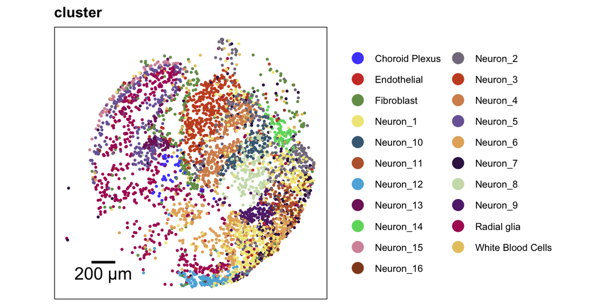

After confirming the parameters, users can proceed to compute the spatial neighborhoods with `findNeighbor()`.

```r
cs <- findNeighbor(cs)
```

Users can optionally visualize the computed spatial neighborhood for a selected spot. These plots highlight the spots being considered as the neighbors of the selected spot and colors them based on the weight assigned. These functions by default show the spot with the most number of neighboring spots, though, users can to try more different spots with specifying `index`.

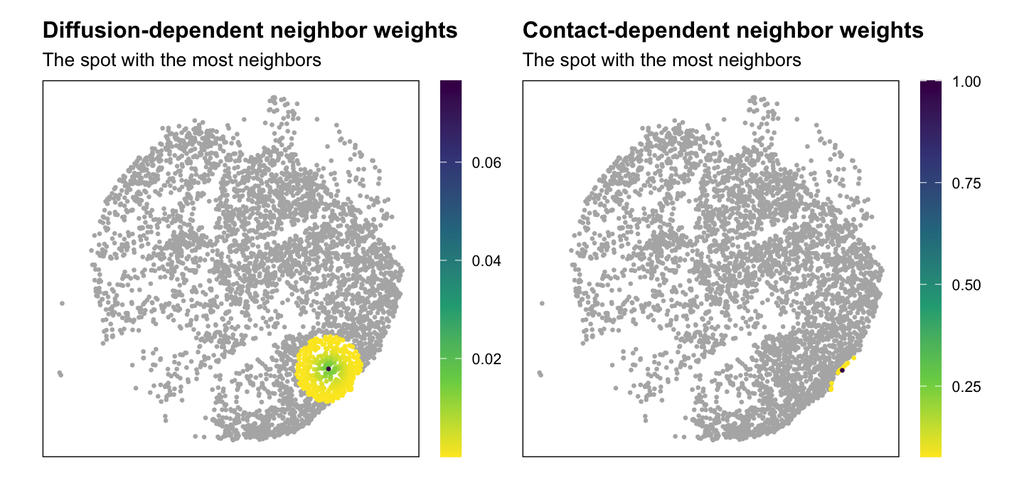

```r
# Must load package "patchwork" for combining plots with `+` operator
plotNeighborDiff(cs) + plotNeighborCont(cs)
```

### Calculate ligand-receptor co-expression and identifying spatially significant interactions

Starting from 2.0.0, CytoSignal exports function `inferLRScore()` to do everything at once. We first impute the received ligand amount $L$ and possessed receptor amount $R$ for each spot by aggregating the gene expression within its spatial neighborhood, weighted by distance. Corresponding neighbor graph is used for different types of interactions as annotated in the database. We take the sum of normalized gene expression for complex components. Then LRscore of each interaction within each spatial neighborhood is calculated by multiplying $L$ and $R$. Each LRscore is further smoothed within its local neighborhood. We apply a permutation test that shuffles the spatial locations to generate a null distribution of LRscore. A one-sided p-value can be then calculated by comparing the observed LRscore with the null distribution. We further perform spatial false discovery rate (FDR) correction to control for multiple hypothesis testing and potential biases caused by cellular density differences. LRscore is stored at `cs@LRScore`, and the spatially corrected FDR is stored at `cs@significance$spatialFDR` as a matrix of spot by interaction size.

- `smoothR` - Optional, whether to impute receptor amount $R$ from contact-dependent neighborhood. This is useful when then spatial resolution is high (e.g. multiple spots per cell) and the data is sparse. Default `FALSE` considers receptor to be intrinsic to each spot.

```r
# Optional, permutation test includes random sampling.
# set the random seed for reproducibility
set.seed(1)
cs <- inferLRScore(cs)
```

Additionally but optionally, we integrate SPARK-X (Sun et al., 2020, Zhu et al., 2021) to further test the spatial variability of the LRscore. Function `inferSpatialVarIntr()` wraps the SPARK-X procedure and stores the test p-values at `cs@significance$sparkx`. External package need to be installed via `devtools::install_github('xzhoulab/SPARK')`.

```r
cs <- inferSpatialVarIntr(cs)
```

The Function `getTopIntr()` is provided to filter interactions by component gene expression and rank interactions by spatial variability (SPARK-X p-value) if available, and the number of significant spatial locations. Here we access the top interactions, by default filtered by limiting them to being significant in at least 100 spatial locations (FDR < 0.05), and having all component genes expressed in at least 100 spots.

```r
topIntrs <- getTopIntr(cs)
# dplyr operation, show top 5 interactions for each type
topIntrs %>%
  group_by(type) %>%
  slice_head(n = 5)
```

```
## # A tibble: 10 × 7
## # Groups:   type [2]
##    interactors   ligands receptors type      alt_name n_signif_spots sparkx_padj
##    <chr>         <chr>   <chr>     <fct>     <chr>             <dbl>       <dbl>
##  1 LRRTM1-NRXN1  Lrrtm1  Nrxn1     contact   ""                 2810           0
##  2 NLGN1-NRXN1   Nlgn1   Nrxn1     contact   ""                 2678           0
##  3 LRRTM1-NRXN2  Lrrtm1  Nrxn2     contact   ""                 2605           0
##  4 CLSTN3-NRXN1  Clstn3  Nrxn1     contact   ""                 2467           0
##  5 FLRT3-ADGRL3  Flrt3   Adgrl3    contact   ""                 2422           0
##  6 CHL1-L1CAM    Chl1    L1cam     diffusion ""                 1993           0
##  7 NTN4-NTRK2    Ntn4    Ntrk2     diffusion ""                 1860           0
##  8 NECTIN1-CADM3 Nectin1 Cadm3     diffusion ""                 1828           0
##  9 SLIT1-ROBO1   Slit1   Robo1     diffusion ""                 1743           0
## 10 DAG1-NRXN3    Dag1    Nrxn3     diffusion ""                 1575           0
```

## Visualization

### General spatial plots of LRscore, metadata, and gene expression

Function `plotIntrSummary()` is provided to visualize the information that is most interesting to users at a glance, including the LRscore, ligand and receptor gene expression, and cluster labels.

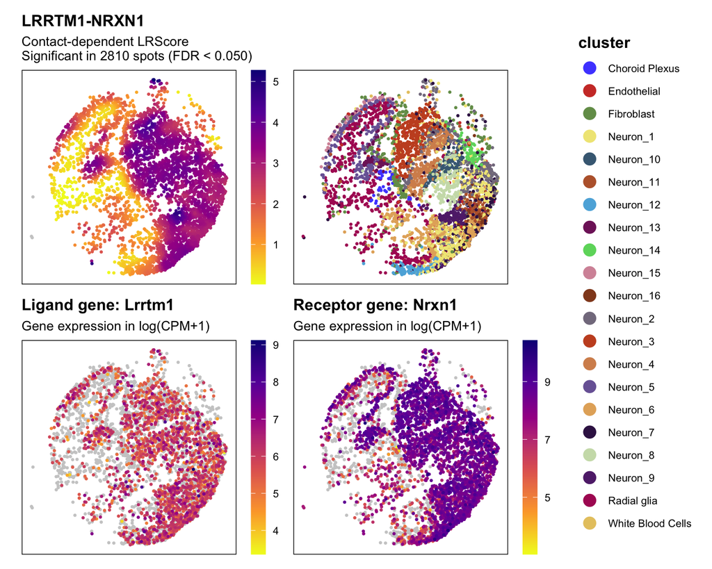

```r
plotIntrSummary(cs, topIntrs[1,])
```

The individual panels above can be separately generated via `plotSpatialLRScore()`, `plotSpatialMetadata()`, and `plotSpatialGene()`. Another wrapper function `plotSpatial()` is also built to flexibly generate patchwork figures that combines any information of these categories, but in a less fine-tuned layout.

**NOTE** - Metadata is located at `cs@metadata`, and a single metadata variable can be conveniently retrieved via a `$` operator (e.g. `cs$total_counts`), like many other container objects in R.

**NOTE** - Default cluster labels must be set via either providing them at object creation (see above), or anytime later via `setCluster()`. The plot can be simply generated with `plotSpatial(cs)`, or `plotSpatialMetadata(cs)`.

### 3D Edge plot

Here we present an edge plot that visualizes the interaction connection in 3D view. We show the spatial coordinates copied into two layers at the top and bottom. In the top layer, we use solid colors to highlight the spots that are tested to receive significant interaction signal. In the bottom, we use solid colors to highlight the sender spots that are in the receivers’ neighborhood and express the ligand genes. Transparent colors are used for spots that do not contribute to the specified interaction. We use lines to connect sender and receiver spot pairs, which indicate interaction event. Given the total number of possible connections can be huge, we only show downsampled connections for clarity.

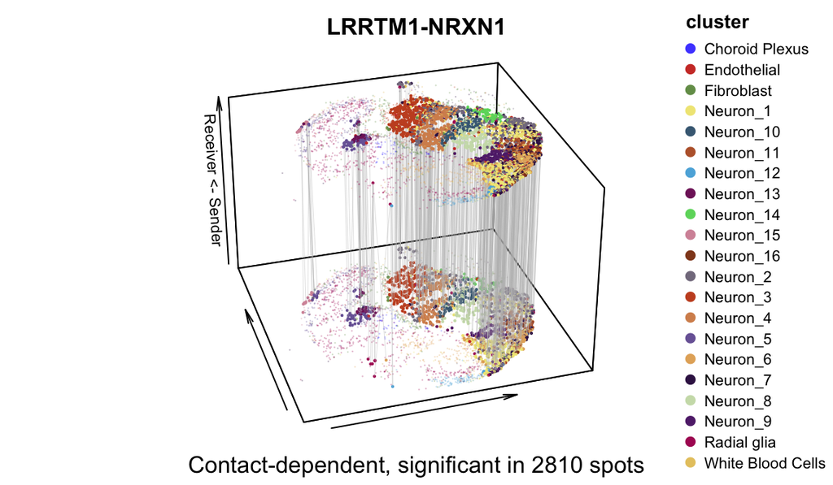

```r
plotEdge2(cs, topIntrs[1,])
```

### Circos plot

A incorporated a circos plot that summarizes the overall cluster-wise interaction frequency. This can be done for a single interaction, a user-defined subset of interactions (e.g. the top ones, the ones sharing the same ligand/receptor, or an annotated ones belonging to the same pathway), or simply all interactions for a overview of the hotspots.

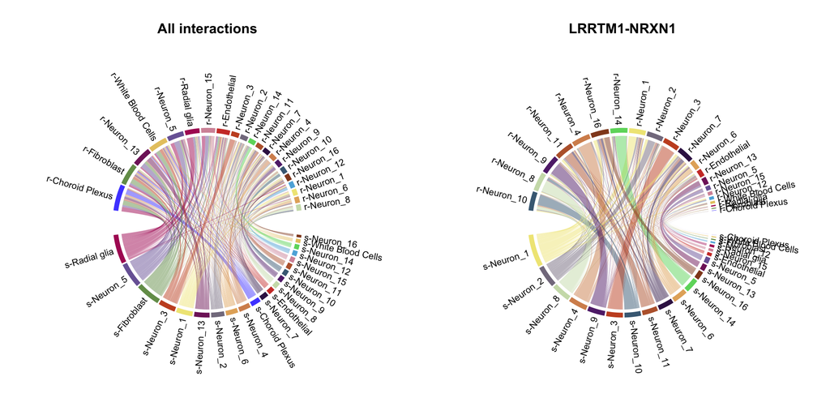

```r
# This type of plot can be organized via R base graphics layout syntax
# Here we preset it to one row and two columns grids
par(mfrow = c(1, 2))
# First show the overview of all interactions
plotCircosNIntr2(cs)
# Next show a specific interaction
plotCircosNIntr2(cs, interaction = topIntrs[1,])
```

## Infering genes associated with interaction activities

Downstream to identifying spatially significant and variable interactions, we provide function `findIntrDEG()` to further identify genes that are associated with the interaction activities. For each interaction, we perform a one-sided Wilcoxon’s rank-sum test on each gene, between the spots that receive significant interaction signal and the spots that do not. The test is done per interaction and per cluster (if available, see NOTE above). For each interaction, the function collects the genes that show significant up-regulation when spots receive significant interaction signal.

```r
intrDEGs <- findIntrDEG(cs, interaction = topIntrs[1,])
intrDEGs$geneSignif[[1]] %>%
  slice_head(n = 5)
```

```
##     gene nCluster  meanLFC effectSize
## 1  Nrxn1        4 1.687697   3.375395
## 2   Nrg3        3 1.616976   2.800685
## 3   Sgcz        2 1.796872   2.541161
## 4  Dscam        2 1.671777   2.364250
## 5 Lrrc4c        3 1.326181   2.297014
```

The returned object `intrDEGs` has a documented structure that stores various information for the analysis. Please see `?csIntrDEG` for the detailed specification of the returned object. In the top genes shown above:

- `nCluster` refers to the number of clusters where the gene is significantly up-regulated when the interaction is significant.
- `meanLFC` is the mean log fold-change of the gene across the clusters where it is significant.
- `effectSize` is the effect size metric that combines the mean log fold-change and number of clusters, which is used for sorting the result here.

The gene set can be further interpreted via GO (gene ontology) term enrichment analysis with external tools. This analysis can be done with any GO tools of preference. We recommend using [GORILLA](https://cbl-gorilla.cs.technion.ac.il/) which we also utilized in our manuscript. Here, we showcase another alternative [g:Profiler](https://biit.cs.ut.ee/gprofiler/gost) that offers an R package gprofiler2 to interactively query the result.

```r
library(gprofiler2)
goRes <- gost(query = intrDEGs$geneSignif$`LRRTM1-NRXN1`$gene, organism = "mmusculus", sources = c("GO:BP", "GO:MF", "GO:CC"))
goRes$result %>%
  dplyr::select(term_name, p_value, source) %>%
  group_by(source) %>%
  slice_head(n = 3)
```

[output not shown]